# Week 10 / Day 3

# Setup

```r
library(tidyverse)
library(modelr)
library(GGally)
library(ggfortify)
library(skimr)
```

```r
house_prices <- read_csv("data/kc_house_data.csv")
```

```r
glimpse(house_prices)
```

```
Rows: 21,613
Columns: 21
$ id            <chr> "7129300520", "6414100192", "5631500400", "24872008…
$ date          <dttm> 2014-10-13, 2014-12-09, 2015-02-25, 2014-12-09, 20…
$ price         <dbl> 221900, 538000, 180000, 604000, 510000, 1225000, 25…
$ bedrooms      <dbl> 3, 3, 2, 4, 3, 4, 3, 3, 3, 3, 3, 2, 3, 3, 5, 4, 3, …
$ bathrooms     <dbl> 1.00, 2.25, 1.00, 3.00, 2.00, 4.50, 2.25, 1.50, 1.0…
$ sqft_living   <dbl> 1180, 2570, 770, 1960, 1680, 5420, 1715, 1060, 1780…
$ sqft_lot      <dbl> 5650, 7242, 10000, 5000, 8080, 101930, 6819, 9711, …
$ floors        <dbl> 1.0, 2.0, 1.0, 1.0, 1.0, 1.0, 2.0, 1.0, 1.0, 2.0, 1…
$ waterfront    <dbl> 0, 0, 0, 0, 0, 0, 0, 0, 0, 0, 0, 0, 0, 0, 0, 0, 0, …
$ view          <dbl> 0, 0, 0, 0, 0, 0, 0, 0, 0, 0, 0, 0, 0, 0, 0, 3, 0, …
$ condition     <dbl> 3, 3, 3, 5, 3, 3, 3, 3, 3, 3, 3, 4, 4, 4, 3, 3, 3, …
$ grade         <dbl> 7, 7, 6, 7, 8, 11, 7, 7, 7, 7, 8, 7, 7, 7, 7, 9, 7,…
$ sqft_above    <dbl> 1180, 2170, 770, 1050, 1680, 3890, 1715, 1060, 1050…
$ sqft_basement <dbl> 0, 400, 0, 910, 0, 1530, 0, 0, 730, 0, 1700, 300, 0…
$ yr_built      <dbl> 1955, 1951, 1933, 1965, 1987, 2001, 1995, 1963, 196…
$ yr_renovated  <dbl> 0, 1991, 0, 0, 0, 0, 0, 0, 0, 0, 0, 0, 0, 0, 0, 0, …
$ zipcode       <dbl> 98178, 98125, 98028, 98136, 98074, 98053, 98003, 98…
$ lat           <dbl> 47.5112, 47.7210, 47.7379, 47.5208, 47.6168, 47.656…
$ long          <dbl> -122.257, -122.319, -122.233, -122.393, -122.045, -…
$ sqft_living15 <dbl> 1340, 1690, 2720, 1360, 1800, 4760, 2238, 1650, 178…
$ sqft_lot15    <dbl> 5650, 7639, 8062, 5000, 7503, 101930, 6819, 9711, 8…
```

```r
summary(house_prices)
```

```
      id                 date                            price
 Length:21613       Min.   :2014-05-02 00:00:00.00   Min.   :  75000
 Class :character   1st Qu.:2014-07-22 00:00:00.00   1st Qu.: 321950
 Mode  :character   Median :2014-10-16 00:00:00.00   Median : 450000
                    Mean   :2014-10-29 04:38:01.96   Mean   : 540088
                    3rd Qu.:2015-02-17 00:00:00.00   3rd Qu.: 645000
                    Max.   :2015-05-27 00:00:00.00   Max.   :7700000
    bedrooms        bathrooms      sqft_living       sqft_lot
 Min.   : 0.000   Min.   :0.000   Min.   :  290   Min.   :    520
 1st Qu.: 3.000   1st Qu.:1.750   1st Qu.: 1427   1st Qu.:   5040
 Median : 3.000   Median :2.250   Median : 1910   Median :   7618
 Mean   : 3.371   Mean   :2.115   Mean   : 2080   Mean   :  15107
 3rd Qu.: 4.000   3rd Qu.:2.500   3rd Qu.: 2550   3rd Qu.:  10688
 Max.   :33.000   Max.   :8.000   Max.   :13540   Max.   :1651359
     floors        waterfront            view          condition
 Min.   :1.000   Min.   :0.000000   Min.   :0.0000   Min.   :1.000
 1st Qu.:1.000   1st Qu.:0.000000   1st Qu.:0.0000   1st Qu.:3.000
 Median :1.500   Median :0.000000   Median :0.0000   Median :3.000
 Mean   :1.494   Mean   :0.007542   Mean   :0.2343   Mean   :3.409
 3rd Qu.:2.000   3rd Qu.:0.000000   3rd Qu.:0.0000   3rd Qu.:4.000
 Max.   :3.500   Max.   :1.000000   Max.   :4.0000   Max.   :5.000
     grade          sqft_above   sqft_basement       yr_built
 Min.   : 1.000   Min.   : 290   Min.   :   0.0   Min.   :1900
 1st Qu.: 7.000   1st Qu.:1190   1st Qu.:   0.0   1st Qu.:1951
 Median : 7.000   Median :1560   Median :   0.0   Median :1975
 Mean   : 7.657   Mean   :1788   Mean   : 291.5   Mean   :1971
 3rd Qu.: 8.000   3rd Qu.:2210   3rd Qu.: 560.0   3rd Qu.:1997
 Max.   :13.000   Max.   :9410   Max.   :4820.0   Max.   :2015
  yr_renovated       zipcode           lat             long
 Min.   :   0.0   Min.   :98001   Min.   :47.16   Min.   :-122.5
 1st Qu.:   0.0   1st Qu.:98033   1st Qu.:47.47   1st Qu.:-122.3
 Median :   0.0   Median :98065   Median :47.57   Median :-122.2
 Mean   :  84.4   Mean   :98078   Mean   :47.56   Mean   :-122.2
 3rd Qu.:   0.0   3rd Qu.:98118   3rd Qu.:47.68   3rd Qu.:-122.1
 Max.   :2015.0   Max.   :98199   Max.   :47.78   Max.   :-121.3
 sqft_living15    sqft_lot15
 Min.   : 399   Min.   :   651
 1st Qu.:1490   1st Qu.:  5100
 Median :1840   Median :  7620
 Mean   :1987   Mean   : 12768
 3rd Qu.:2360   3rd Qu.: 10083
 Max.   :6210   Max.   :871200
```

# 1.

Tidy up the data ready for regression:

- You might like to think about removing some or all of `date`, `id`, `sqft_living15`, `sqft_lot15` and `zipcode` (`lat` and `long` provide a better measure of location in any event).

```r
house_prices_clean <- house_prices %>%
  select(-c("date", "id", "sqft_living15", "sqft_lot15", "zipcode"))
```

- Have a think about how to treat `waterfront`. Should we convert its type?

```r
house_prices_clean <- house_prices_clean %>%
  mutate(waterfront = if_else(waterfront == 1, TRUE, FALSE))
```

- We converted `yr_renovated` into a `renovated` logical variable, indicating whether the property had ever been renovated. You may wish to do the same.

```r
house_prices_clean <- house_prices_clean %>%
  mutate(renovated = if_else(yr_renovated == 0, FALSE, TRUE)) %>%
  select(-yr_renovated)
```

- Have a think about how to treat `view`, `condition` and `grade`? Are they interval or categorical ordinal data types?

Based on information from the data dictionary:

`view` appears to be categorical ordinal, with levels 0, 1, 2, 3, & 4 `condition` appears to be categorical ordinal, with levels 0, 1, 2, 3, 4 & 5 `grade` appears to be categorical ordinal, with levels 0, 1, 2, 3, 4, 5, 6, 7, 8, 9, 10, 11, 12, 13

To better represent this, all 3 variables will be updated to factor types with set levels. I did consider binning the `grade` values; however, I was unsure of how consistent size bins could be set. The two bins identified in the dictionary are from 1-3 and 11-13, leaving 7 remaining possible values which cannot be placed in bins of the same size (eg. 3). Therefor, for now, I will proceed with analysis with `grade` values as they are.

```r
house_prices_clean <- house_prices_clean %>%
  mutate(view = factor(view, levels = c(0, 1, 2, 3, 4)),
         condition = factor(condition, levels = c(0, 1, 2, 3, 4, 5)),
         grade = factor(grade, levels = c(0, 1, 2, 3, 4, 5, 6, 7, 8, 9, 10, 11, 12, 13)))
```

# 2.

Check for aliased variables using the alias() function (this takes in a formula object and a data set). Remove variables that lead to an alias. Check the ‘Elements of multiple regression’ lesson for a dropdown containing further information on finding aliased variables in a dataset.

```r
alias(price ~ ., data = house_prices_clean)
```

```
Model :
price ~ bedrooms + bathrooms + sqft_living + sqft_lot + floors +
    waterfront + view + condition + grade + sqft_above + sqft_basement +
    yr_built + lat + long + renovated

Complete :
              (Intercept) bedrooms bathrooms sqft_living sqft_lot floors
sqft_basement  0           0        0         1           0        0
              waterfrontTRUE view1 view2 view3 view4 condition2 condition3
sqft_basement  0              0     0     0     0     0          0
              condition4 condition5 grade3 grade4 grade5 grade6 grade7
sqft_basement  0          0          0      0      0      0      0
              grade8 grade9 grade10 grade11 grade12 grade13 sqft_above
sqft_basement  0      0      0       0       0       0      -1
              yr_built lat long renovatedTRUE
sqft_basement  0        0   0    0
```

From the above `sqft_basement` appears to be aliased with `sqft_living` and `sqft_above`. I will therefore remove `sqft_basement` to avoid multicollinearity.

```r
house_prices_trim <- house_prices_clean %>%
  select(-sqft_basement)
```

Re-running the `alias()` function on `house_prices_trim` confirms that there are no remaining aliases.

```r
alias(price ~ ., data = house_prices_trim)
```

```
Model :
price ~ bedrooms + bathrooms + sqft_living + sqft_lot + floors +
    waterfront + view + condition + grade + sqft_above + yr_built +
    lat + long + renovated
```

# 3.

Systematically build a regression model containing up to four main effects (remember, a main effect is just a single predictor with coefficient), testing the regression diagnostics as you go.

Remember, if you are not sure whether including a categorical predictor is statistically justified, run an anova() test passing in the models with- and without the categorical predictor and check the p-value of the test.

## 1st Predictor

### Use `ggpairs()` To Identify First Predictor

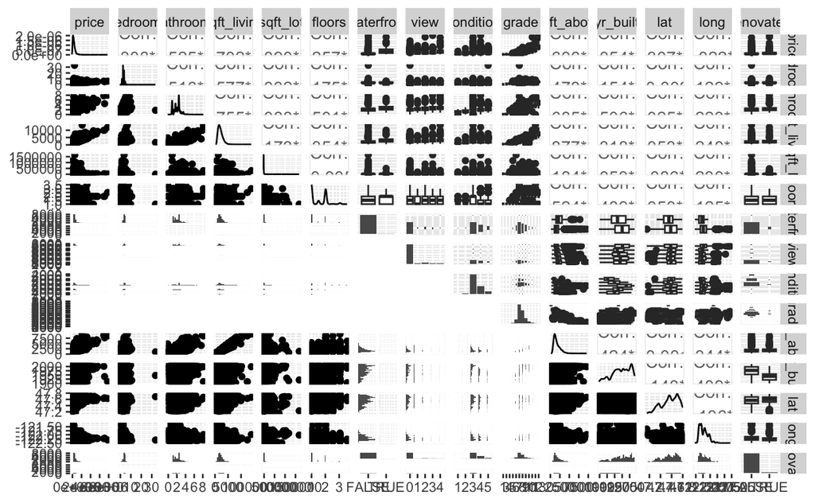

```r
house_prices_trim %>%
  ggpairs(progress = FALSE)
```

`sqft_living` has a strong positive Correlation Coefficient of 0.702, the highest of the returned Correlation Coefficients, and is indicated as being statistically significant. I will therefor use this as the first predictor in my model.

### Build Model With 1st Predictor

When first generating my diagnostic plots, these failed. I believe this was due to a skewed distribtion of `sqft_living`. At the same time I noticed that the `price` distribution was also skewed. I have therefor created a new log transformation of both variables (`sqft_living_log`, `price_log`) below which both have more normal distributions and I will use these in my model

```r
house_prices_trim <- house_prices_trim %>%
  mutate(price_log = log(price)) %>%
  select(-price)
```

```r
house_prices_trim <- house_prices_trim %>%
  mutate(sqft_living_log = log(sqft_living)) %>%
  select(-sqft_living)
```

Re-running `ggpairs()` using these new variables, there still appears to be a strong correlation between `price_log` and `sqft_living_log`. Calculating the Correlation Coefficient confirms there is a strong positive correlation, so I proceed in using `sqft_living_log` as my first predictor.

```r
house_prices_trim %>%
  summarise(cor(price_log, sqft_living_log))
```

| cor(price_log, sqft_living_log) |
| --- |
| 0.6749126 |

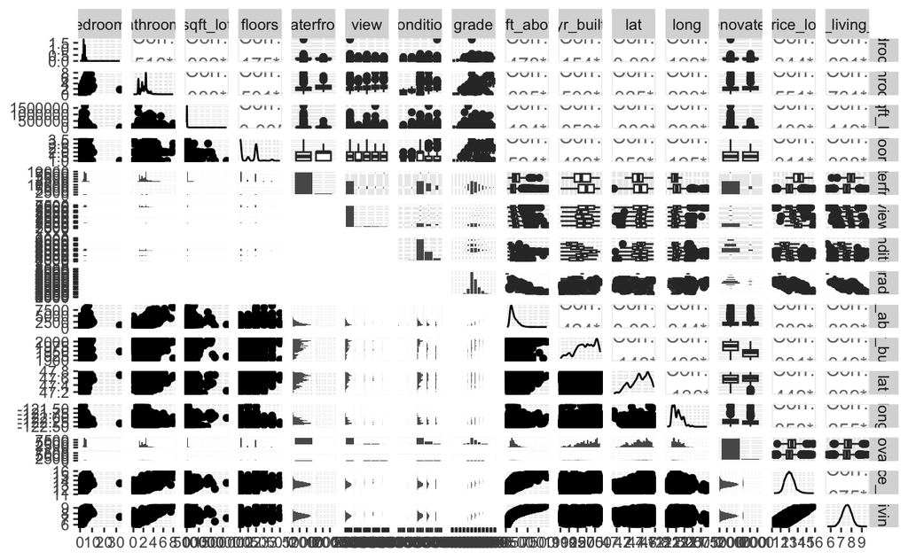

```r
house_prices_trim %>%
  ggpairs(progress = FALSE)
```

```r
model_1 <- lm(price_log ~ sqft_living_log, data = house_prices_trim)
```

### Check Diagnostic Plots

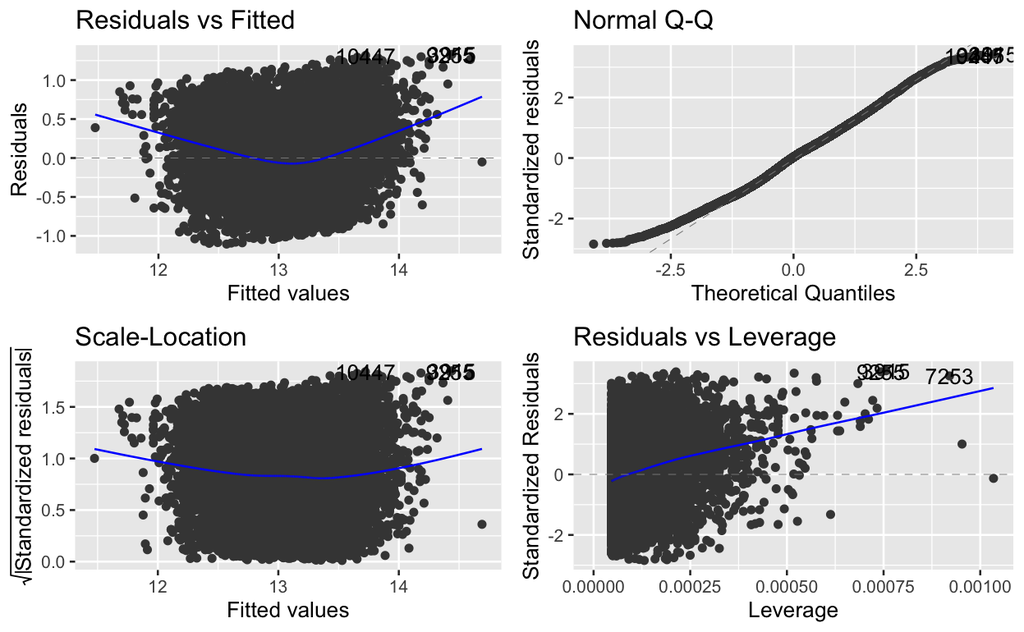

```r
autoplot(model_1)
```

- Plot 1: Some evidence of a pattern - unsure if passable or not.
- Plot 2: Distribution of standardised residuals appears fairly normal.
- Plot 3: No evidence of funneling.

For the purposes of allowing me to proceed in the context of the homework I’m going to accept the above diagnostic plots as being ok and proceed.

### Check Model Effectiveness

```r
summary(model_1)
```

```
Call:
lm(formula = price_log ~ sqft_living_log, data = house_prices_trim)

Residuals:
     Min       1Q   Median       3Q      Max
-1.10511 -0.29300  0.01262  0.25701  1.33011

Coefficients:
                Estimate Std. Error t value Pr(>|t|)
(Intercept)     6.729916   0.047062   143.0   <2e-16 ***
sqft_living_log 0.836771   0.006223   134.5   <2e-16 ***
---
Signif. codes:  0 ‘***’ 0.001 ‘**’ 0.01 ‘*’ 0.05 ‘.’ 0.1 ‘ ’ 1

Residual standard error: 0.3886 on 21611 degrees of freedom
Multiple R-squared:  0.4555,    Adjusted R-squared:  0.4555
F-statistic: 1.808e+04 on 1 and 21611 DF,  p-value: < 2.2e-16
```

- r2 = 0.4555, meaning model explains 46% of variation in `price_log`.
- Residual Standard Error = 0.3886 on 21611 degrees of freedom
- Impact of predictor `sqft_living_log` is statistically significant based on p-value of <2e-16.

I will therefor keep `sqft_living_log` in my model.

## 2nd Predictor

### Add Residuals

```r
house_prices_resid <- house_prices_trim %>%
    add_residuals(model = model_1) %>%
    select(-c(price_log, sqft_living_log))
```

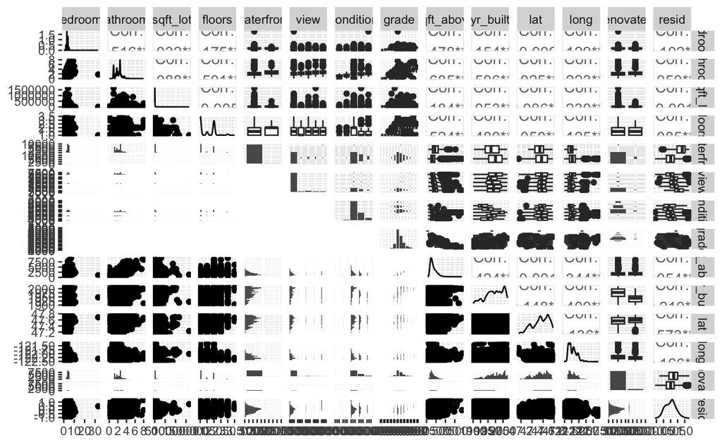

```r
ggpairs(house_prices_resid, progress = FALSE)
```

`lat` has a moderately positive Correlation Coefficient of 0.573 with the residuals and is indicated as being statistically significant. I will therefor use this as the second predictor in my model.

```r
model_2 <- lm(price_log ~ sqft_living_log + lat, data = house_prices_trim)
```

### Check Diagnostic Plots

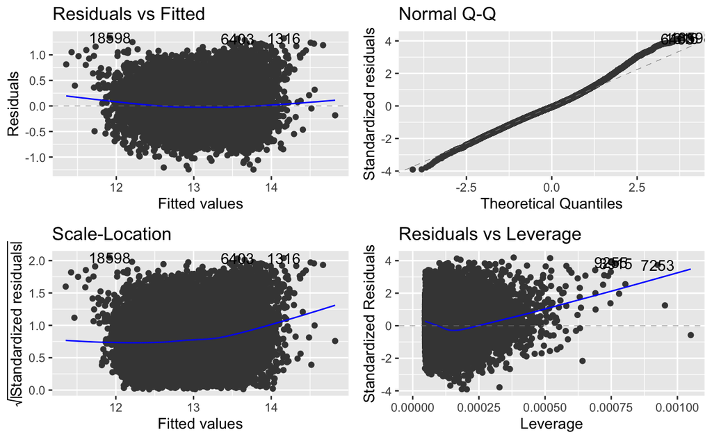

```r
autoplot(model_2)
```

- Plot 1: No strong evidence of a pattern, residuals appear to be independent.
- Plot 2: Distribution of standardised residuals appears fairly normal.
- Plot 3: Some evidence of an upward trend, but no evidence of funneling.

I will accept the above diagnostic plots as being ok and proceed.

### Check Model Effectiveness

```r
summary(model_2)
```

```
Call:
lm(formula = price_log ~ sqft_living_log + lat, data = house_prices_trim)

Residuals:
     Min       1Q   Median       3Q      Max
-1.24482 -0.20493 -0.02026  0.18499  1.33457

Coefficients:
                  Estimate Std. Error t value Pr(>|t|)
(Intercept)     -69.628822   0.743652  -93.63   <2e-16 ***
sqft_living_log   0.816108   0.005104  159.90   <2e-16 ***
lat               1.608803   0.015647  102.82   <2e-16 ***
---
Signif. codes:  0 ‘***’ 0.001 ‘**’ 0.01 ‘*’ 0.05 ‘.’ 0.1 ‘ ’ 1

Residual standard error: 0.3185 on 21610 degrees of freedom
Multiple R-squared:  0.6344,    Adjusted R-squared:  0.6343
F-statistic: 1.875e+04 on 2 and 21610 DF,  p-value: < 2.2e-16
```

- r2 = 0.6343, meaning model explains 63% of variation in `price_log`.
- Residual Standard Error = 0.3185 on 21610 degrees of freedom
- Impact of predictor `sqft_living_log` is statistically significant based on p-value of <2e-16.
- Impact of predictor `lat` is statistically significant based on p-value of <2e-16.

I will therefor keep both `sqft_living_log` and `lat` in my model.

## 3rd Predictor

### Add Residuals

```r
house_prices_resid <- house_prices_trim %>%
    add_residuals(model = model_2) %>%
    select(-c(price_log, sqft_living_log, lat))
```

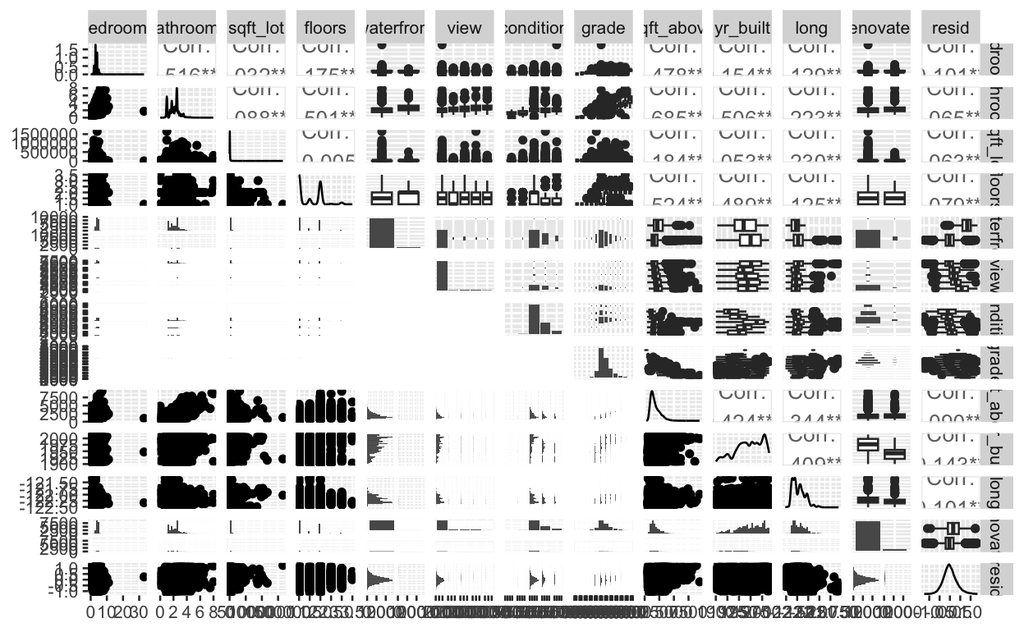

```r
ggpairs(house_prices_resid, progress = FALSE)
```

Based on the boxplot displayed, `waterfront` appears as though it may have a correlation to the residuals. I will use this as the third predictor in my model.

```r
model_3 <- lm(price_log ~ sqft_living_log + lat + waterfront,
              data = house_prices_trim)
```

### Check Diagnostic Plots

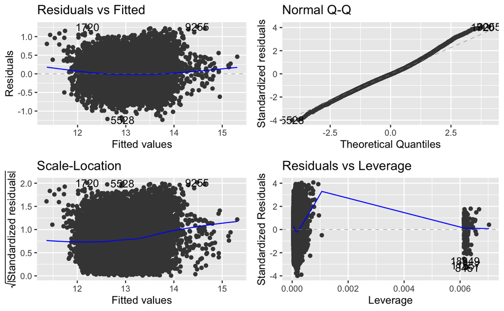

```r
autoplot(model_3)
```

- Plot 1: No strong evidence of a pattern, residuals appear to be independent.
- Plot 2: Distribution of standardised residuals appears fairly normal.
- Plot 3: No evidence of funneling.

I will accept the above diagnostic plots as being ok and proceed.

### Check Model Effectiveness

```r
summary(model_3)
```

```
Call:
lm(formula = price_log ~ sqft_living_log + lat + waterfront,
    data = house_prices_trim)

Residuals:
     Min       1Q   Median       3Q      Max
-1.24306 -0.19986 -0.01568  0.18502  1.26446

Coefficients:
                  Estimate Std. Error t value Pr(>|t|)
(Intercept)     -69.945148   0.726656  -96.26   <2e-16 ***
sqft_living_log   0.803287   0.005003  160.57   <2e-16 ***
lat               1.617365   0.015290  105.78   <2e-16 ***
waterfrontTRUE    0.786990   0.024547   32.06   <2e-16 ***
---
Signif. codes:  0 ‘***’ 0.001 ‘**’ 0.01 ‘*’ 0.05 ‘.’ 0.1 ‘ ’ 1

Residual standard error: 0.3112 on 21609 degrees of freedom
Multiple R-squared:  0.651, Adjusted R-squared:  0.6509
F-statistic: 1.343e+04 on 3 and 21609 DF,  p-value: < 2.2e-16
```

- r2 = 0.6509, meaning model explains 65% of variation in `price_log`.
- Residual Standard Error = 0.3112 on 21609 degrees of freedom
- Impact of predictor `sqft_living_log` is statistically significant based on p-value of <2e-16.
- Impact of predictor `lat` is statistically significant based on p-value of <2e-16.
- Impact of predictor `waterfrontTRUE` is statistically significant based on p-value of <2e-16.

I will therefor keep `sqft_living_log`, `lat` and `waterfront` in my model.

## 4th Predictor

### Add Residuals

```r
house_prices_resid <- house_prices_trim %>%
    add_residuals(model = model_3) %>%
    select(-c(price_log, sqft_living_log, lat, waterfront))
```

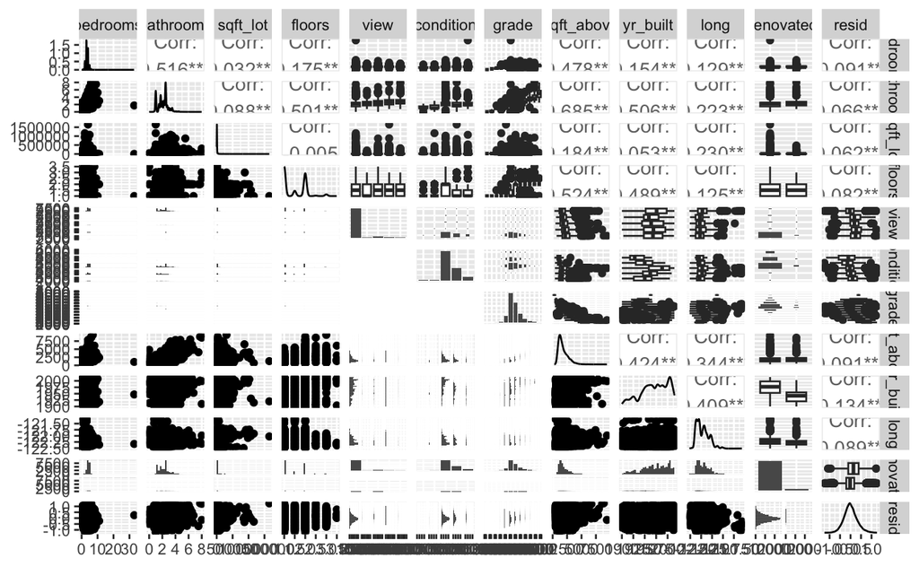

```r
ggpairs(house_prices_resid, progress = FALSE)
```

```r
model_4 <- lm(price_log ~ sqft_living_log + lat + waterfront + grade,
              data = house_prices_trim)
```

### Check Diagnostic Plots

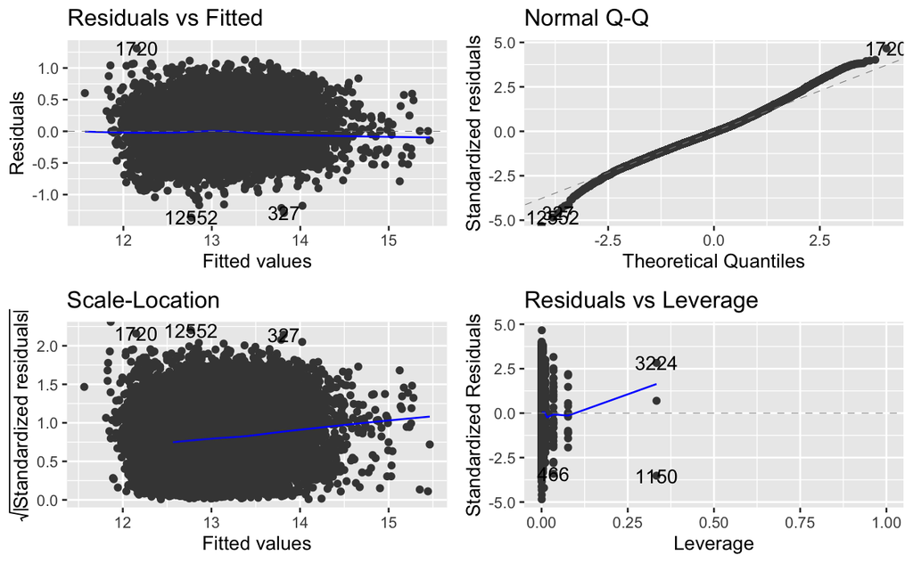

```r
autoplot(model_4)
```

- Plot 1: No strong evidence of a pattern, residuals appear to be independent.
- Plot 2: Distribution of standardised residuals appears fairly normal.
- Plot 3: Some evidence of an upward trend, but no evidence of funneling.

I will accept the above diagnostic plots as being ok and proceed.

### Check Model Effectiveness

```r
summary(model_4)
```

```
Call:
lm(formula = price_log ~ sqft_living_log + lat + waterfront +
    grade, data = house_prices_trim)

Residuals:
     Min       1Q   Median       3Q      Max
-1.36069 -0.18165 -0.01587  0.16684  1.30856

Coefficients:
                  Estimate Std. Error t value Pr(>|t|)
(Intercept)     -62.356237   0.722503 -86.306  < 2e-16 ***
sqft_living_log   0.474653   0.006789  69.910  < 2e-16 ***
lat               1.504889   0.013925 108.072  < 2e-16 ***
waterfrontTRUE    0.705368   0.022276  31.664  < 2e-16 ***
grade3            0.173160   0.324406   0.534 0.593503
grade4            0.002066   0.285755   0.007 0.994233
grade5           -0.054406   0.281594  -0.193 0.846800
grade6            0.025315   0.281126   0.090 0.928249
grade7            0.121547   0.281164   0.432 0.665529
grade8            0.274413   0.281252   0.976 0.329232
grade9            0.474583   0.281382   1.687 0.091692 .
grade10           0.657341   0.281534   2.335 0.019560 *
grade11           0.849208   0.281857   3.013 0.002591 **
grade12           1.079762   0.283163   3.813 0.000138 ***
grade13           1.482597   0.292336   5.072 3.98e-07 ***
---
Signif. codes:  0 ‘***’ 0.001 ‘**’ 0.01 ‘*’ 0.05 ‘.’ 0.1 ‘ ’ 1

Residual standard error: 0.2809 on 21598 degrees of freedom
Multiple R-squared:  0.7157,    Adjusted R-squared:  0.7155
F-statistic:  3884 on 14 and 21598 DF,  p-value: < 2.2e-16
```

- r2 = 0.7155, meaning model explains 72% of variation in `price_log`.
- Residual Standard Error = 0.2809 on 21598 degrees of freedom
- Impact of predictor `sqft_living_log` is statistically significant based on p-value of <2e-16.
- Impact of predictor `lat` is statistically significant based on p-value of <2e-16.
- Impact of predictor `waterfrontTRUE` is statistically significant based on p-value of <2e-16.
- Impact of some of levels of `grade` are statistically significant based on their p-values but not others.

To support a decision on whether or not `grade` should be kept in the model I will use an Anova.

```r
anova(model_3, model_4)
```

```
Analysis of Variance Table

Model 1: price_log ~ sqft_living_log + lat + waterfront
Model 2: price_log ~ sqft_living_log + lat + waterfront + grade
  Res.Df    RSS Df Sum of Sq      F    Pr(>F)
1  21609 2092.4
2  21598 1704.2 11    388.18 447.22 < 2.2e-16 ***
---
Signif. codes:  0 ‘***’ 0.001 ‘**’ 0.01 ‘*’ 0.05 ‘.’ 0.1 ‘ ’ 1
```

The results of the Anova suggest that adding `grade` as a predictor to the model did make a statistically significant difference. I will therefor keep `grade` in my model as the 4th predictor.